# A1 Q1

```python
import matplotlib.pyplot as plt
import numpy as np
import _pickle as pickle
```

## Q1

## Gradient descent method

Since the objective function is given by: $2x_1^2 + x_2^2 +x_3^4$

And because autograd is banned, I analytically calculated the first derivative of the function w.r.t $\mathbf{x}$ as： $$\begin{bmatrix} 4x_1 & 2x_2 & 4x_3^3 \end{bmatrix}$$

And we have $\mathbf{x_0}$ given by $$\begin{bmatrix} 1 \\ -4 \\ 2\end{bmatrix}$$

sub in x0 to gradient descent update rule:

```python
x0 = np.array([1. ,-4., 2.])

def f(x):
    '''
    x: array
    return the value of the objective function with given x
    '''
    f = lambda x: 2*x[0]**2 + x[1]**2 + x[2]**4
    return f(x)

def df_dx_analytical(x):
    '''
    x:array
    analytically differentiated the objectvive function, returns the value of 1st derivative of obj function with given x
    '''
    dx = np.array([4*x[0], 2*x[1], 4*(x[2]**3)])
    return dx

def df_dx2_analytical(x):
    '''
    x:array
    analytically calculated the 2nd derivative of obj function, returns the value of the hessian matrix with given x
    '''
    dx = np.array([[4,0,0],[0,2,0],[0, 0, 12*x[2]**2]])
    return dx


def gradient_descent(x, a = 0.1, i = 20, rel_error = 0.001):
    '''
    x: array
    using gradient descent method, calculate optimal solution and optimal value given an initial solution
    '''
    it = 0
    error = 1
    f_history = np.zeros(i)
    while it in range(i) and error >= rel_error:
        x_old = np.copy(x)                      #assign x(t-1)
        obj_old = f(x_old)                      #calculate x(t-1) objective value
        g = df_dx_analytical(x_old)                        #calculate gradient
        delta = - a*g                           #calculate delta
        x = x_old + delta                       #calculate x(t)
        obj_value = f(x)                        #calculate x(t) objective value
        error = abs((obj_value - obj_old)/obj_old)              #calculate rel error
        f_history[it] = obj_value                               #add objective value for later plotting
        it += 1                                 #add one more step  to iteration counter
    return x,obj_value, f_history

np.set_printoptions(formatter={'float_kind':'{:f}'.format})

opt_sol, opt_value, obj_history= gradient_descent(x0)
print('optimal solution by gradient descent method is', opt_sol)
print('optimal value by gradient descent method is', opt_value)
```

```
optimal solution by gradient descent method is [0.000037 -0.046117 -0.227772]
optimal value by gradient descent method is 0.004818289181363018
```

*Part B.*

Now with a function that plots the objective value history, we can see clearly that the objective value is showing a diminishing trend when decreasing as iteration increases, but the updating rule of the method always takes a step to reduce the loss towards the direction of the negative gradient

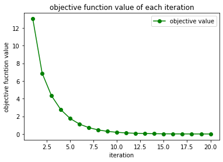

```python
def visualize_obj(y, it=20):

    '''
    y: array
    plot the objective value by iterations
    '''

    plt.plot(range(1, it+1), y, 'go-', label = "objective value")
    plt.xlabel("iteration")
    plt.ylabel("objective fucntion value")
    plt.title("objective function value of each iteration")
    plt.legend()
    plt.show()

visualize_obj(obj_history)
```

## Newton's Method

similarly I analytically calculated the second derivative w.r.t x , which is a hessian matrix: $$\begin{bmatrix} 4 & 0 & 0 \\ 0 & 2 & 0 \\ 0 & 0 & 12x_3^2 \end{bmatrix}$$

then sub in the x0 values to the updating rule of Newton's method to start taking steps:

```python
def newton(x, i = 20, rel_error = 0.001):
    '''
    x: array
    using newton's method, calculate optimal solution and optimal value given an initial solution
    '''
    it = 0
    error = 1
    f_history = np.zeros(i)
    while it in range(i) and error >= rel_error:
        x_old = np.copy(x)                      #assign x(t-1)
        obj_old = f(x_old)                      #calculate x(t-1) objective value
        g = df_dx_analytical(x_old)                        #calculate gradient
        a = np.linalg.inv(df_dx2_analytical(x_old))
        delta = np.dot(a, g)                   #calculate delta
        x = x_old - delta                       #calculate x(t)
        obj_value = f(x)                        #calculate x(t) objective value
        error = abs((obj_value - obj_old)/obj_old)              #calculate rel error
        f_history[it] = obj_value
        it += 1

    return x, obj_value, f_history

newt_sol, newt_val, newt_history = newton(x0)
print('optimal solution derived by Newton method is', newt_sol)
print('optimal value derived by Newton method is', newt_val)
```

```
optimal solution derived by Newton method is [0.000000 0.000000 0.000601]
optimal value derived by Newton method is 1.3086371897047623e-13
```

Part B.

Gradient descent method uses a user defined learning rate to optimize the problem, Newton's method uses the second derivative of the objective function to work as the learning rate to find the roots of the objective function

Part C.

Main issues with Newton's Method are:

1. the objective function must have second derivative
2. the second derivative of the objective function must be invertible
3. Newton's method may lead to a saddle point